# Part B. Computing the language fractionalization index

1. Read the .csv file you just created with the counts of Tweets per language and country. Use this dataset to compute an index of language fractionalization at the country level using the formula in equation (1) in the paper by Alesina et al (2003). Feel free to do this in any way that you consider most efficient, either using `dplyr` or with functions and loops.

```r
library(readxl)
library(tidyverse)
library(countrycode)
library(stats)
library(gridExtra)

country_lang <- read_csv("country_language_distribution.csv")
```

```r
# To get the total number of tweets for each country.
country_sum <- country_lang %>% group_by(country_info) %>% summarise(SUM = sum(n))
country_sum
```

```
## # A tibble: 62 x 2
##    country_info   SUM
##    <chr>        <dbl>
##  1 AFG             46
##  2 ALB             48
##  3 AND             19
##  4 ARM             38
##  5 AUT            493
##  6 AZE            111
##  7 BEL           1274
##  8 BGR            141
##  9 BIH            282
## 10 BLR            264
## # … with 52 more rows
```

Spread the sum of each country by country name.

```r
country_with_sum <- country_lang %>% left_join(country_sum)
country_index <- country_with_sum[order(country_with_sum$country_info),]
country_index
```

```
## # A tibble: 966 x 4
##    country_info lang      n   SUM
##    <chr>        <chr> <dbl> <dbl>
##  1 AFG          en       26    46
##  2 AFG          fa       10    46
##  3 AFG          in        1    46
##  4 AFG          nl        1    46
##  5 AFG          ps        4    46
##  6 AFG          und       4    46
##  7 ALB          de        1    48
##  8 ALB          en       15    48
##  9 ALB          et        3    48
## 10 ALB          fr        2    48
## # … with 956 more rows
```

To caculate the index using the equation.

```r
country_index <- country_index %>% group_by(country_info) %>% summarise(index = 1- sum((n/SUM)^2))
country_index
```

```
## # A tibble: 62 x 2
##    country_info index
##    <chr>        <dbl>
##  1 AFG          0.617
##  2 ALB          0.717
##  3 AND          0.681
##  4 ARM          0.551
##  5 AUT          0.729
##  6 AZE          0.635
##  7 BEL          0.777
##  8 BGR          0.739
##  9 BIH          0.668
## 10 BLR          0.279
## # … with 52 more rows
```

2. Compute some descriptive statistics on this data, either through tables or graphs. Which countries have the highest and lowest levels of language fractionalization?

some statistics.

```r
cat("mean: ", mean(country_index$index),"\n")
```

```
## mean:  0.5733251
```

```r
cat("median: ", median(country_index$index),"\n")
```

```
## median:  0.6372092
```

```r
cat("sd: ", sd(country_index$index))
```

```
## sd:  0.202402
```

###### FRO,GRL, TKM only have one type of languge in our tweeting data, so their index will be 0. GGY has the loweset level among all positive countrirs which is 0.1723356.

###### MKD has the the highest level of language fractionalization which is 0.8470648.

```r
lowest_countries <- (country_index %>% arrange(index))[1:4,]
highest_country <- (country_index %>% arrange(desc(index)))[1,]
print(lowest_countries)
```

```
## # A tibble: 4 x 2
##   country_info index
##   <chr>        <dbl>
## 1 FRO          0
## 2 GRL          0
## 3 TKM          0
## 4 GGY          0.172
```

```r
print(highest_country)
```

```
## # A tibble: 1 x 2
##   country_info index
##   <chr>        <dbl>
## 1 MKD          0.847
```

3. Read the first sheet in `2003_fractionalization.xls` into R. Keep only the country and language fractionalization columns. (You can export the .xls file into a .csv file in Excel first if that’s esier.)

Then, merge this data frame with the country-level fractionalization index you computed using Twitter data. This may be somewhat painful due to the different spellings of the countries. You can use the `countrycode` package to help you, or manually fix some of the country names so that they’re the same across data sources. Throughout this process, check the sample size of the initial and final files to make sure you didn’t drop any relevant countries.

```r
# read the excel sheet in.
df <- read_xls("2003_fractionalization.xls", skip = 1)

df <- (df %>% select(Country, Language))[-1,]

df$Language <- as.numeric(df$Language)
df_countrycode <- countrycode(df$Country, origin = 'country.name', destination = 'genc3c')
df$Country[!is.na(df_countrycode)] <- df_countrycode[!is.na(df_countrycode)]

# To see what are include in NA
df$Country[is.na(df_countrycode)]
```

```
## [1] "Micronesia"
## [2] "Netherlands Antilles"
## [3] "Serbia/Montenegro (Yugoslavia)"
## [4] "Yugoslavia (pre 1991)"
## [5] NA
## [6] "Source Key: eb=Encyclopedia Brit, cia=CIA, sm=Scarrit and Mozaffar"
## [7] "lev=Levinson, wdm=World Directory of Minorities, census=national census data"
```

Since there is no code for it, I kept the first 4 and drop the other 3.

```r
df$Country[is.na(df_countrycode)][5:7] <- NA

cat("Number of row before drop row:", nrow(df), "\n")
```

```
## Number of row before drop row: 218
```

```r
# drop
df <- df[complete.cases(df$Country),]

cat("Number of row after drop row:", nrow(df), "\n")
```

```
## Number of row after drop row: 215
```

```r
names(df) <- c("country_info", "xls_index")

my_metric <- country_index %>% left_join(df, by = "country_info")

my_metric
```

```
## # A tibble: 62 x 3
##    country_info index xls_index
##    <chr>        <dbl>     <dbl>
##  1 AFG          0.617    0.614
##  2 ALB          0.717    0.0399
##  3 AND          0.681    0.685
##  4 ARM          0.551    0.129
##  5 AUT          0.729    0.152
##  6 AZE          0.635    0.205
##  7 BEL          0.777    0.541
##  8 BGR          0.739    0.303
##  9 BIH          0.668    0.675
## 10 BLR          0.279    0.467
## # … with 52 more rows
```

4. Compare your new metric with the measure on fractionalization from Alesina et al. What is the correlation between the two? For which countries do you find any differences? Can you explain why? Use any statistical or graphical methods you consider appropriate to answer this question.

After observe the table, we decide to take 0.3 as threhold

value to show huge difference.

```r
difference <- 0.3

correlation <- cor(my_metric$index, my_metric$xls_index,use = "complete.obs")

cat("The correlation is:", correlation)
```

```
## The correlation is: 0.08935256
```

```r
with_difference <- my_metric %>% filter(abs(index-xls_index) > difference)

with_difference
```

```
## # A tibble: 31 x 3
##    country_info index xls_index
##    <chr>        <dbl>     <dbl>
##  1 ALB          0.717    0.0399
##  2 ARM          0.551    0.129
##  3 AUT          0.729    0.152
##  4 AZE          0.635    0.205
##  5 BGR          0.739    0.303
##  6 CZE          0.690    0.323
##  7 DEU          0.732    0.164
##  8 DNK          0.700    0.105
##  9 EST          0.807    0.494
## 10 FIN          0.571    0.141
## # … with 21 more rows
```

We consider number of tweets under 1000 is not representative

as the sample size is too small to draw a conclusion

```r
new_df <- country_sum   %>% filter(country_info %in% with_difference$country_info)


new_df %>% filter(SUM > 1000)
```

```
## # A tibble: 6 x 2
##   country_info   SUM
##   <chr>        <dbl>
## 1 DEU           4397
## 2 FRA           8541
## 3 GBR          36168
## 4 ITA           5129
## 5 POL           1192
## 6 PRT           1791
```

Take GBR as an example to explor why there is difference.

```r
xls_data <- read_excel("2003_fractionalization.xls", skip = 5, sheet = 3)
```

```
## * Language -> Language...4
## * Language -> Language...7
```

```r
names(xls_data) <- c("Source", "Date", "Country", "Language",
                     "Number", "Percent", "Language_Index","Notes")

xls_data <- xls_data %>% select(Country, Language, Percent)

xls_data$Country <- countrycode(xls_data$Country, origin = 'country.name', destination = 'genc3c')
xls_data
```

```
## # A tibble: 1,707 x 3
##    Country Language        Percent
##    <chr>   <chr>             <dbl>
##  1 AFG     Pashai            0.618
##  2 AFG     Balochi           0.927
##  3 AFG     Dari (Persian)   32.0
##  4 AFG     Nuristani group   0.773
##  5 AFG     Pamir group       0.618
##  6 AFG     Pashto           52.4
##  7 AFG     Turkmen           1.93
##  8 AFG     Uzbek             8.81
##  9 AFG     Other             1.89
## 10 ALB     Albanian         98.0
## # … with 1,697 more rows
```

```r
GBR_xls <-xls_data %>% filter(Country == "GBR")
GBR_tweet <- country_lang %>% filter(country_info == "GBR")
GBR_tweet
```

```
## # A tibble: 45 x 3
##    country_info lang      n
##    <chr>        <chr> <dbl>
##  1 GBR          ar      293
##  2 GBR          ca       51
##  3 GBR          cs       22
##  4 GBR          cy       59
##  5 GBR          da       26
##  6 GBR          de       47
##  7 GBR          el       96
##  8 GBR          en    25196
##  9 GBR          es      625
## 10 GBR          et       34
## # … with 35 more rows
```

```r
sum_n <-sum(GBR_tweet$n)
p_en <- GBR_tweet$n[GBR_tweet$lang == "en"]/sum_n
p_cy <- GBR_tweet$n[GBR_tweet$lang == "cy"]/sum_n

p_other <- 1- p_en - p_cy


GBR_tweet <- tibble(Country = GBR_xls$Country,
                  Language = GBR_xls$Language,
                  Percent =c(p_en, 0, p_cy, p_other)*100)
```

After some data reshaping, we get the dataframe for detail language used in the UK, bothe for the Alesina et al data and our data. See below

```r
GBR_xls
```

```
## # A tibble: 4 x 3
##   Country Language     Percent
##   <chr>   <chr>          <dbl>
## 1 GBR     English       97.3
## 2 GBR     Scots-Gaelic   0.134
## 3 GBR     Welsh          0.955
## 4 GBR     UK Other       1.62
```

```r
GBR_tweet
```

```
## # A tibble: 4 x 3
##   Country Language     Percent
##   <chr>   <chr>          <dbl>
## 1 GBR     English       69.7
## 2 GBR     Scots-Gaelic   0
## 3 GBR     Welsh          0.163
## 4 GBR     UK Other      30.2
```

To take a close look, we drew two pie chart.

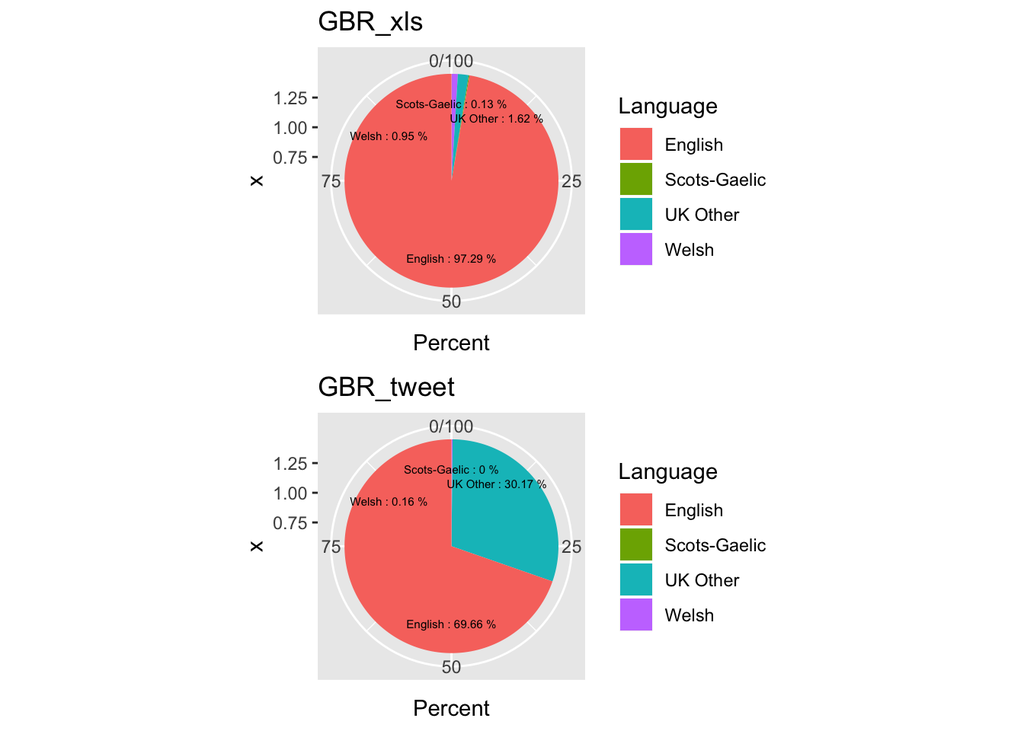

```r
pie1 <- GBR_xls %>% ggplot(aes(x=1, y=Percent, fill = Language)) + geom_bar(stat = "identity")  + labs(title="GBR_xls") +  coord_polar("y", start=0) +   geom_text(aes(x=1.2,y=c(50,0,85,10),label=paste(Language,":",round(Percent/sum(Percent)*100,2),"%")),size=2)

pie2 <- GBR_tweet %>% ggplot(aes(x=1, y=Percent, fill = Language)) + geom_bar(stat = "identity")  + labs(title="GBR_tweet") +  coord_polar("y", start=0) +   geom_text(aes(x=1.2,y=c(50,0,85,10),label=paste(Language,":",round(Percent/sum(Percent)*100,2),"%")),size=2)

grid.arrange(pie1, pie2)
```

##### This difference may be caused by selection bias.

##### As we can see from the pie chart that in 2001, with Alesina et al, 97% of people speaking English, and in our tweet data, Engilish Tweet only contains 69%, which may because of the selection bias that, we selected tweets with GPS info, and it is quite posible that freign people who tour to the UK are more likely to share their location and tweets afterall, this is the whole point of travelling!

Save the file to disk.

```r
write.csv(my_metric, "my_metric.csv")
```